# Gender Diversity

2021-06-30

```r
library(GenderDiversity)
```

## GenderDiversity package

GenderDiversity is a package developed to find possible gender bias in the data. This package is based on the work of Dr. [A. Day et al. Chem. Sci., 2020,11, 2277-2301](https://pubs.rsc.org/en/content/articlelanding/2020/sc/c9sc04090k#!divAbstract). The idea is to create a tool that is helpful to analyse data for gender diversity in the editorial field. This package could also be used for every other analysis where there are binary data related to female and male. The gender is assigned based on the first name, using as corpus the following data set: https://github.com/OpenGenderTracking/globalnamedata The data source take into account data from:

- The United States
  - Social Security Administration
- United Kingdom
  - UK Office of National Statistics
  - Northern Ireland Statistics and Research Administration
  - Scotland General Register Office

## Example data set

In this vignette the example data frame `authors` contains random names (first and last name for each row), country and publication_years from 2016 to 2020. This data set allow us to check the gender bias in the case of submission of articles to a journal.

```r
head(authors)
```

```
#>   first_name  last_name country_code publication_years
#> 1     Claire     Driver           UK              2019
#> 2   Jedidiah el-Mansoor           CH              2018
#> 3     Hayden        Kim           FR              2016
#> 4      Diana    Sanchez           CH              2018
#> 5       Cody    Sterett           CH              2020
#> 6     Shanea al-Rahaman           FR              2017
```

## Assign gender based on first name

The function `assign_gender` assign the plausible gender reading the data frame containing the column `first_name`. It creates in output a data frame, which is equal to the input one, with a new column containing the variable `gender`.

```r
library(dplyr)
library(ggplot2)

authors_df <- assign_gender(data_df = authors, first_name_col = first_name)

head(authors_df)
```

```
#>   first_name  last_name country_code publication_years gender
#> 1     Claire     Driver           UK              2019      F
#> 2   Jedidiah el-Mansoor           CH              2018      M
#> 3     Hayden        Kim           FR              2016      M
#> 4      Diana    Sanchez           CH              2018      F
#> 5       Cody    Sterett           CH              2020      M
#> 6     Shanea al-Rahaman           FR              2017      F
```

We can now explore how many female, male and unknown there are in the data frame, using the function `count` from `dplyr` package.

```r
## Count how many female, male and unknown gender there are in the data
authors_df %>% count(gender)
```

```
#>   gender   n
#> 1      F 396
#> 2      M 428
#> 3      U 176
```

```r
## per gender and country
authors_df %>% count(gender, country_code)
```

```
#>    gender country_code  n
#> 1       F           CH 81
#> 2       F           FR 84
#> 3       F           IT 71
#> 4       F           UK 92
#> 5       F           US 68
#> 6       M           CH 91
#> 7       M           FR 83
#> 8       M           IT 77
#> 9       M           UK 79
#> 10      M           US 98
#> 11      U           CH 32
#> 12      U           FR 28
#> 13      U           IT 35
#> 14      U           UK 35
#> 15      U           US 46
```

## Calculate baseline and plot basic chart.

`GenderDiversity` calculate the female baseline using the function `baseline`, which will be used for further statistical calculation and for the graphics. The baseline for female is calculated as:

$$baseline = \frac{Female_{submission}}{Female_{submission} + Male_{submission}}$$

The baseline give the possibility to compare different variables. It is also possible to calculate the baseline for different level, such as year or country, or another variables. The level represents the variable we want to use to make the comparison.

In the following case we calculate the baseline for the years range 2016-2019 to compare with 2020 for the whole data set.

```r
## calculates baseline for the year range 2016-2019
baseline_female <- baseline(data_df = authors_df %>%
                              filter(publication_years %in% seq(2016, 2019)),
                            gendercol = gender)
baseline_female
```

```
#> [1] 49
```

## Create a simple bar chart showing the number of male and female.

The package has the function `calculate_binom_baseline`, which apply the binomial test where the number of female is the nuber of success in a Bernoulli experiment and it uses the baseline value as expected probability of success. This function find if there is any statistical significance in the difference between female and male. Before to calculate the binomial the input data frame is reshape in a new data form.

In first instance we calculate the count of female for the 2020. The variable we want to make the comparison in this case is `publication_years`. This variable will allow to make a comparison with the previous years range. In the present package we call `level` the variable used for comparison. The function `reshape_for_binomial` creates a new input data frame containing the female and male percentage, the total for level (`total_for_level`), which is the sum of female, male and unknown and the sum of female and male (`total_female_male`).

```r
## Create a data frame that containg only the data from 2020 and
## the coung of the variable gender.
female_count_2020 <- authors_df %>%
  filter(publication_years == 2020) %>%
  count(gender)

## create a new data frame to be used for the binomial calculation.
df_gender <- reshape_for_binomials(data_df = female_count_2020,
                                   gendercol = "gender",
                                   level = 2020)

df_gender
```

```
#> # A tibble: 1 x 8
#>   female  male unknown level total_for_level total_female_male female_percentage
#>    <dbl> <dbl>   <dbl> <fct>           <dbl>             <dbl>             <dbl>
#> 1     71    90      31 2020              192               161              44.1
#> # … with 1 more variable: male_percentage <dbl>
```

The function `calculate_binomial_baseline` calculates also the lower CI, upper CI and significance. The default value of the confidence level is 0.95. Before perform the graphics the function `gender_total_df` pivots the data in longer format, which means that the data frame has now increase the number of row and decrease the number of columns. Because it will create the variable `gender` that contains the values for female, male and unknown. The function `gender_bar_chart` creates a bar chart showing the number of female, male and unknown.

```r
## Calculate the binomial
## Create a new column with the baseline and calculate the binomial.

df_gender <- df_gender %>%
  calculate_binom_baseline(baseline_female = baseline_female)

df_gender
```

```
#> # A tibble: 1 x 15
#>   female  male unknown level total_for_level total_female_male female_percentage
#>    <dbl> <dbl>   <dbl> <fct>           <dbl>             <dbl>             <dbl>
#> 1     71    90      31 2020              192               161              44.1
#> # … with 8 more variables: male_percentage <dbl>, lower_CI <dbl>,
#> #   upper_CI <dbl>, lower_CI_count <dbl>, upper_CI_count <dbl>, baseline <dbl>,
#> #   adjusted_p_value <dbl>, significance <chr>
```

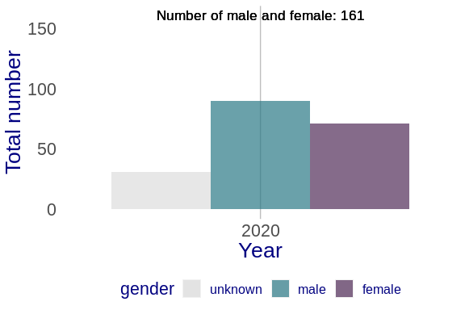

```r
## Create a bar chart of showing the number of male, female and unknown gender
gender_total_df(df_gender, level) %>%
  gender_bar_chart("Year",
                 "Total number", "Number of male and female:")
```

## Create barchart with significance bar and baseline.

The function `stacked_bar_chart` create a stacked bar chart using the percentage. This chart shows information about the baseline and the percentage of males and females.

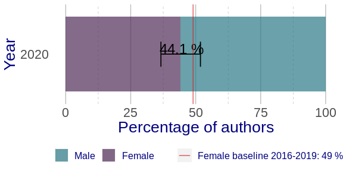

```r
percent_df(df_gender) %>%
  stacked_bar_chart(baseline_female, "Year", "Percentage of authors",
                      "Female baseline 2016-2019:") + coord_flip()
```

## Balloon plot

```r
balloon_plot(data_df = authors_df, first_name = first_name, gender = gender)
```

[output not shown]

## Multibaseline analysis

We can now see how to calculate the baseline for several level of the same variable and how to generate the graphics. In the example below we use the function `sapply` to generate the baselines value for `c("UK", "US")`. This generates a numeric vector containing two values, one for “US” and the second for “UK”. As before we reshape now the data with the function `reshape_for_binomials` and after we apply the `calcultate_binom_baseline`.

```r
## calculate binomials for us and uk

UK_US_df <- reshape_for_binomials(authors_df %>%
                                     filter(country_code %in% c("UK", "US"),
                                            publication_years == 2020) %>%
                                     count(gender, country_code),
                                  gender, country_code)


baseline_uk_us <- sapply(UK_US_df$country_code, function(x) {
  baseline(authors_df %>%
             filter(country_code %in% x,
                    publication_years %in% seq(2016, 2019)), gender)
})

UK_US_binom <- calculate_binom_baseline(UK_US_df, baseline_uk_us)

UK_US_binom
```

```
#> # A tibble: 2 x 16
#>   country_code female  male unknown level total_for_level total_female_male
#>   <chr>         <dbl> <dbl>   <dbl> <fct>           <dbl>             <dbl>
#> 1 UK               18    16       6 UK                 40                34
#> 2 US               15    23       7 US                 45                38
#> # … with 9 more variables: female_percentage <dbl>, male_percentage <dbl>,
#> #   lower_CI <dbl>, upper_CI <dbl>, lower_CI_count <dbl>, upper_CI_count <dbl>,
#> #   baseline <dbl>, adjusted_p_value <dbl>, significance <chr>
```

A bullet chart displays the baseline and the female and male percentage for US and UK

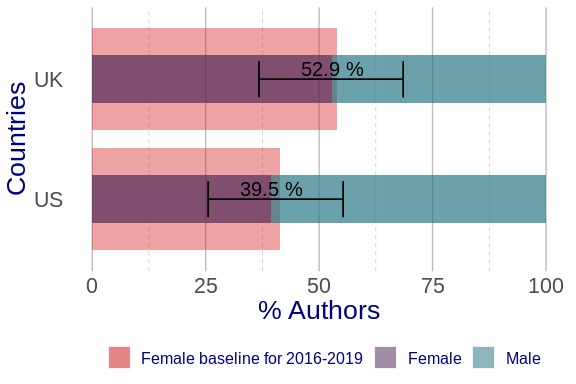

```r
percent_uk_us <- percent_df(UK_US_binom)

bullet_chart <- bullet_chart(percent_uk_us, baseline_uk_us,
                             x_title = "Countries", y_title = "% Authors",
                             baseline_label = "Female baseline for 2016-2019")
bullet_chart
```

```r
## calculate binomials for us and uk

UK_df <- reshape_for_binomials(authors_df %>%
                                     filter(country_code == "UK") %>%
                                     count(gender, publication_years),
                               gender, publication_years)

UK_df
```

```
#> # A tibble: 5 x 9
#>   publication_years female  male unknown level total_for_level total_female_male
#>               <int>  <dbl> <dbl>   <dbl> <fct>           <dbl>             <dbl>
#> 1              2016     22    15       9 2016               46                37
#> 2              2017     20    17       8 2017               45                37
#> 3              2018     16    17       3 2018               36                33
#> 4              2019     16    14       9 2019               39                30
#> 5              2020     18    16       6 2020               40                34
#> # … with 2 more variables: female_percentage <dbl>, male_percentage <dbl>
```

```r
## create a baseline vector containing values for each year from 2016 to 2020.
baseline_fr <- sapply(seq(2016, 2020), function(x) {
  baseline(authors_df %>%
             filter(country_code == "FR", publication_years %in% x), gender)
})

UK_binom <- calculate_binom_baseline(UK_df, baseline_female = baseline_fr)

UK_binom
```

```
#> # A tibble: 5 x 16
#>   publication_years female  male unknown level total_for_level total_female_male
#>               <int>  <dbl> <dbl>   <dbl> <fct>           <dbl>             <dbl>
#> 1              2016     22    15       9 2016               46                37
#> 2              2017     20    17       8 2017               45                37
#> 3              2018     16    17       3 2018               36                33
#> 4              2019     16    14       9 2019               39                30
#> 5              2020     18    16       6 2020               40                34
#> # … with 9 more variables: female_percentage <dbl>, male_percentage <dbl>,
#> #   lower_CI <dbl>, upper_CI <dbl>, lower_CI_count <dbl>, upper_CI_count <dbl>,
#> #   baseline <dbl>, adjusted_p_value <dbl>, significance <chr>
```

The line chart on the top of the bullet chart is the total number of gender in this case per year.

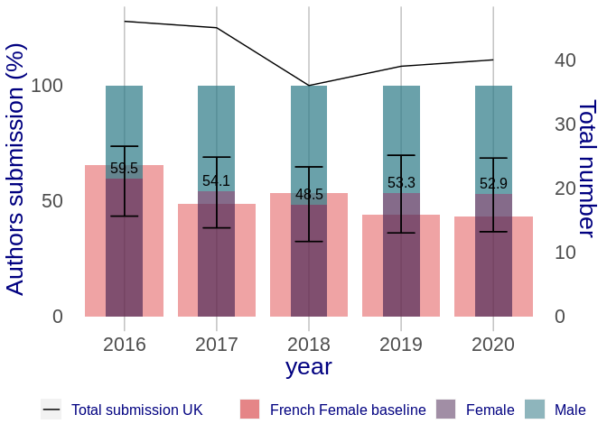

```r
## Calculate the total number of submission per country and per year
percent_uk <- percent_df(UK_binom)
## calculate the number of submission from UK
total_uk <- authors_df %>%
  filter(country_code == "UK") %>%
  count(publication_years) %>%
  mutate(publication_years = factor(publication_years,
                                    levels = publication_years))
## conversion factor to create the second y-axis
c <- min(total_uk$n) / 100
bullet_line_chart(percent_uk, baseline_fr, "year", "Authors submission (%)",
                  "French Female baseline", total_uk, publication_years, c = c,
                  "Total number", "Total submission UK")
```